# Reproducibility of the results

The goal of this file is to reproduce all of the experiments made by Mathieu Acher on his blog right here : https://blog.mathieuacher.com/FootballAnalysis-xG-COVIDHome/. We will do the same graphs and statitics tests on each league of the website https://understat.com/ adding the last years. Firstly, we scrapped data from 6 leagues on understat and then store it in the data_leagues repository as pandas dataframes. The scrapping code can be seen in Data_Scrapping.py file.

```python
# Imports
import pandas as pd
import matplotlib.pyplot as plt
import os
import scipy.stats as stats
import numpy as np
from IPython.display import display
```

```python
leagues = ['La_liga', 'EPL', 'Bundesliga', 'Serie_A', 'Ligue_1', 'RFPL']
```

The following function plots ever xPoints and results at home or away from all leagues in leagues list. We succeeded to have the same graphs than the first experiments. We also added recent years.

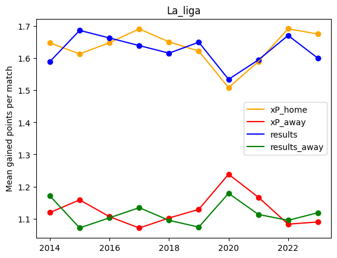

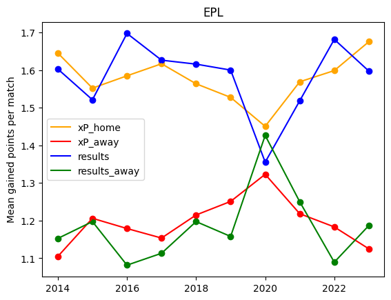

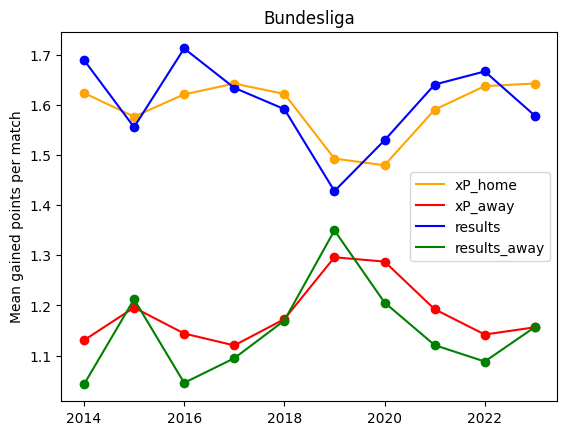

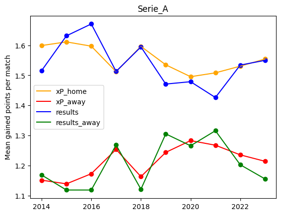

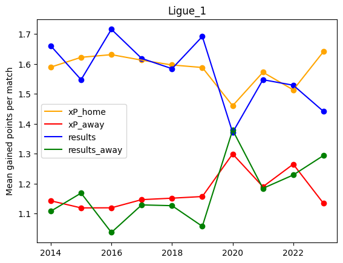

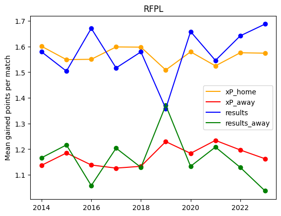

```python
def create_graph(league):
    data = pd.read_csv(os.path.join('data_leagues', league + '.csv'))

    # Extraire les probabilités de forecast
    data['forecast_home'] = data['forecast'].apply(lambda x: eval(x))
    data['forecast_away'] = data['forecast'].apply(lambda x: eval(x))
    data['goals'] = data['goals'].apply(lambda x: eval(x))

    # Calculer les points attendus (xP) pour domicile et extérieur
    data['xP_home'] = data['forecast_home'].apply(lambda f: 3 * float(f['w']) + 1 * float(f['d']))
    data['xP_away'] = data['forecast_away'].apply(lambda f: 3 * float(f['l']) + 1 * float(f['d']))
    data['results'] = data['goals'].apply(lambda f: 3 if float(f['h']) > float(f['a']) else 1 if float(f['h']) == float(f['a']) else 0)
    data['results_away'] = data['goals'].apply(lambda f: 3 if float(f['a']) > float(f['h']) else 1 if float(f['h']) == float(f['a']) else 0)


    # Calculer la moyenne de xP pour les équipes à domicile et à l'extérieur par saison
    average_xP_home = data.groupby('year')['xP_home'].mean()
    average_xP_away = data.groupby('year')['xP_away'].mean()
    average_results = data.groupby('year')['results'].mean()
    average_results_away = data.groupby('year')['results_away'].mean()

    #Création graphe
    fig, ax = plt.subplots()
    plt.title(league)
    ax.plot(average_xP_home.index, average_xP_home, color="orange", label="xP_home")
    ax.scatter(average_xP_home.index, average_xP_home, color="orange", marker="o")
    ax.plot(average_xP_away.index, average_xP_away, color="red", label="xP_away")
    ax.scatter(average_xP_away.index, average_xP_away, color="red", marker="o")
    ax.plot(average_results.index, average_results, color="blue", label="results")
    ax.scatter(average_results.index, average_results, color="blue", marker="o")
    ax.plot(average_results_away.index, average_results_away, color="green", label="results_away")
    ax.scatter(average_results_away.index, average_results_away, color="green", marker="o")

    plt.ylabel("Mean gained points per match")
    plt.legend(fontsize=10)
    plt.show()
for league in leagues:
    create_graph(league)
```

This experiment reproduces the comparison between home and away of both points and xPoints.

```python
def diff_points(leagues):
    df_leagues = pd.DataFrame()
    df_results = pd.DataFrame()
    for league in leagues:
        data = pd.read_csv(os.path.join('data_leagues', league + '.csv'))
        data['forecast_home'] = data['forecast'].apply(lambda x: eval(x))
        data['forecast_away'] = data['forecast'].apply(lambda x: eval(x))
        data['goals'] = data['goals'].apply(lambda x: eval(x))

        data['xP_home'] = data['forecast_home'].apply(lambda f: 3 * float(f['w']) + 1 * float(f['d']))
        data['xP_away'] = data['forecast_away'].apply(lambda f: 3 * float(f['l']) + 1 * float(f['d']))
        data['results'] = data['goals'].apply(lambda f: 3 if float(f['h']) > float(f['a']) else 1 if float(f['h']) == float(f['a']) else 0)
        data['results_away'] = data['goals'].apply(lambda f: 3 if float(f['a']) > float(f['h']) else 1 if float(f['h']) == float(f['a']) else 0)

        data['xG_home'] = data['xG'].apply(lambda x: float(eval(x)['h']))
        data['xG_away'] = data['xG'].apply(lambda x: float(eval(x)['a']))

        data['league'] = league
        data['year'] = data['year']

        df_results = pd.concat([df_results, data[['league', 'year', 'results', 'results_away', 'xP_home', 'xP_away', 'xG_home', 'xG_away']]], ignore_index=True)

        results_home = data.groupby('year')['results'].sum()
        results_away = data.groupby('year')['results_away'].sum()
        xp_home = data.groupby('year')['xP_home'].sum()
        xp_away = data.groupby('year')['xP_away'].sum()

        df = pd.DataFrame()
        df["diff_points"] = results_home - results_away
        df["diff_points_xp"] = xp_home - xp_away
        df["league"] = league
        df["year"] = df.index
        df.reset_index(drop=True, inplace=True)
        df_leagues = pd.concat([df_leagues, df], ignore_index=True)

    df_leagues.set_index('league', inplace=True)
    df_leagues.set_index('year', append=True, inplace=True)
    return df_leagues, df_results
    #.relabel_index(["row 1", "row 2"], axis=0)

def style_formatter(leagues):
    df_leagues,_ = diff_points(leagues)
    return df_leagues.style \
    .format(precision=0, thousands=".", decimal=",") \
    .format_index(str.upper, axis=1) \
    .bar(subset= ["diff_points", "diff_points_xp"], color = ['#b0351a', '#069215'], align=0, vmin=df_leagues["diff_points"].min(), vmax=df_leagues["diff_points"].max(), height=60,
         width=80, props="width: 200px; border-right: 1px solid black;")

style_formatter(leagues)
```

| league | year | DIFF_POINTS | DIFF_POINTS_XP |
| --- | --- | --- | --- |
| La_liga | 2014 | 159 | 201 |
|  | 2015 | 234 | 173 |
|  | 2016 | 213 | 206 |
|  | 2017 | 192 | 236 |
|  | 2018 | 198 | 209 |
|  | 2019 | 219 | 188 |
|  | 2020 | 135 | 103 |
|  | 2021 | 183 | 161 |
|  | 2022 | 219 | 231 |
|  | 2023 | 183 | 223 |
| EPL | 2014 | 171 | 205 |
|  | 2015 | 123 | 131 |
|  | 2016 | 234 | 154 |
|  | 2017 | 195 | 176 |
|  | 2018 | 159 | 132 |
|  | 2019 | 168 | 105 |
|  | 2020 | -27 | 48 |
|  | 2021 | 102 | 133 |
|  | 2022 | 225 | 158 |
|  | 2023 | 156 | 209 |
| Bundesliga | 2014 | 198 | 151 |
|  | 2015 | 105 | 116 |
|  | 2016 | 204 | 146 |
|  | 2017 | 165 | 160 |
|  | 2018 | 129 | 137 |
|  | 2019 | 24 | 60 |
|  | 2020 | 99 | 59 |
|  | 2021 | 159 | 122 |
|  | 2022 | 177 | 152 |
|  | 2023 | 129 | 149 |
| Serie_A | 2014 | 132 | 170 |
|  | 2015 | 195 | 180 |
|  | 2016 | 210 | 161 |
|  | 2017 | 93 | 98 |
|  | 2018 | 180 | 165 |
|  | 2019 | 63 | 111 |
|  | 2020 | 81 | 81 |
|  | 2021 | 42 | 92 |
|  | 2022 | 126 | 112 |
|  | 2023 | 150 | 129 |
| Ligue_1 | 2014 | 210 | 170 |
|  | 2015 | 144 | 191 |
|  | 2016 | 258 | 195 |
|  | 2017 | 186 | 177 |
|  | 2018 | 174 | 169 |
|  | 2019 | 177 | 120 |
|  | 2020 | -3 | 61 |
|  | 2021 | 138 | 145 |
|  | 2022 | 114 | 94 |
|  | 2023 | 45 | 155 |
| RFPL | 2014 | 99 | 111 |
|  | 2015 | 69 | 87 |
|  | 2016 | 147 | 99 |
|  | 2017 | 75 | 113 |
|  | 2018 | 108 | 111 |
|  | 2019 | -3 | 67 |
|  | 2020 | 126 | 95 |
|  | 2021 | 81 | 70 |
|  | 2022 | 123 | 91 |
|  | 2023 | 156 | 99 |

```python
def cohen_d(group1, group2):
    n1, n2 = len(group1), len(group2)

    mean1, mean2 = np.mean(group1), np.mean(group2)
    std1, std2 = np.std(group1, ddof=1), np.std(group2, ddof=1)
    s_pooled = np.sqrt(((n1 - 1) * std1**2 + (n2 - 1) * std2**2) / (n1 + n2 - 2))

    d = (mean1 - mean2) / s_pooled
    return d

def perform_statistical_tests_on_results(df):
    results = []
    grouped = df.groupby('league')
    for league, group in grouped:
        for year in group['year'].unique():
            subset = group[group['year'] == year]
            if len(subset) < 2:
                continue

            home_results = subset['results']
            away_results = subset['results_away']
            home_xPoints = subset['xP_home']
            away_xPoints = subset['xP_away']
            home_xG = subset['xG_home']
            away_xG = subset['xG_away']

            wilco_result, wilco_result_pvalue = stats.wilcoxon(home_results, away_results)
            wilco_xPoints, wilco_xPoints_pvalue = stats.wilcoxon(home_xPoints, away_xPoints)
            wilco_xG, wilco_xG_pvalue = stats.wilcoxon(home_xG, away_xG)

            results.append({
                'league': league,
                'year': year,
                'wilco-result': wilco_result,
                'wilco-result-pvalue': wilco_result_pvalue,
                'result-cohend': cohen_d(home_results, away_results),
                'wilco-xPoints' : wilco_xPoints,
                'wilco-xPoints-pvalue': wilco_xPoints_pvalue,
                'xPoints-cohend': cohen_d(home_xPoints, away_xPoints),
                'wilco-xG': wilco_xG,
                'wilco-xG-pvalue': wilco_xG_pvalue,
                'xG-cohend' : cohen_d(home_xG, away_xG)
            })

    results_df = pd.DataFrame(results)
    return results_df

def style_formatter_proba(dataframe):
    # Fonction pour la coloration conditionnelle

    def color_wilco(val):
        color = 'red' if val > 0.05 else ''
        return f'color: {color};'

    def color_cohend(val):
        color = '#F4C430' if val < 0.2 else ''
        return f'background-color: {color}'

    def zebra_style(row_index):
        return "background-color: #f8f9fa;" if row_index % 2 == 0 else "background-color: white;"


    # Application du style combiné
    return (
        dataframe.style
        .format(precision=2, decimal=",")
        .format_index(str.upper, axis=1)
        # Appliquer une alternance de couleurs sur les lignes (zebra-striping)
        .apply(lambda row: [zebra_style(row.name)] * len(dataframe.columns), axis=1)
        # Texte noir par défaut
        .set_properties(**{"color": "black", "font-family": "Times New Roman", "font-size": "1.3em"})
        .map(color_wilco, subset=["wilco-result-pvalue", "wilco-xPoints-pvalue", "wilco-xG-pvalue"])
        .map(color_cohend, subset=["result-cohend", "xPoints-cohend", "xG-cohend"])
    )

_, df_leagues = diff_points(leagues)
results_df = perform_statistical_tests_on_results(df_leagues)
style_formatter_proba(results_df)
```

|  | LEAGUE | YEAR | WILCO-RESULT | WILCO-RESULT-PVALUE | RESULT-COHEND | WILCO-XPOINTS | WILCO-XPOINTS-PVALUE | XPOINTS-COHEND | WILCO-XG | WILCO-XG-PVALUE | XG-COHEND |
| --- | --- | --- | --- | --- | --- | --- | --- | --- | --- | --- | --- |
| 0 | Bundesliga | 2014 | 8887,50 | 0,00 | 0,51 | 15127,50 | 0,00 | 0,66 | 15014,00 | 0,00 | 0,49 |
| 1 | Bundesliga | 2015 | 11800,00 | 0,02 | 0,26 | 17547,00 | 0,00 | 0,46 | 17430,00 | 0,00 | 0,40 |
| 2 | Bundesliga | 2016 | 9553,00 | 0,00 | 0,52 | 15789,50 | 0,00 | 0,60 | 15813,00 | 0,00 | 0,47 |
| 3 | Bundesliga | 2017 | 9408,00 | 0,00 | 0,42 | 14812,50 | 0,00 | 0,67 | 14736,00 | 0,00 | 0,51 |
| 4 | Bundesliga | 2018 | 11115,00 | 0,00 | 0,32 | 16635,00 | 0,00 | 0,52 | 16636,00 | 0,00 | 0,40 |
| 5 | Bundesliga | 2019 | 13742,50 | 0,60 | 0,06 | 20412,50 | 0,05 | 0,23 | 20551,00 | 0,06 | 0,17 |
| 6 | Bundesliga | 2020 | 10848,00 | 0,03 | 0,25 | 20471,00 | 0,05 | 0,23 | 20344,00 | 0,04 | 0,22 |
| 7 | Bundesliga | 2021 | 10530,00 | 0,00 | 0,40 | 17146,00 | 0,00 | 0,48 | 17281,00 | 0,00 | 0,33 |
| 8 | Bundesliga | 2022 | 9976,00 | 0,00 | 0,45 | 15665,50 | 0,00 | 0,60 | 15673,00 | 0,00 | 0,46 |
| 9 | Bundesliga | 2023 | 10283,00 | 0,00 | 0,33 | 16091,00 | 0,00 | 0,57 | 16040,00 | 0,00 | 0,46 |
| 10 | EPL | 2014 | 16560,00 | 0,00 | 0,35 | 21690,50 | 0,00 | 0,74 | 21473,00 | 0,00 | 0,56 |
| 11 | EPL | 2015 | 15892,00 | 0,01 | 0,25 | 27262,00 | 0,00 | 0,44 | 27235,00 | 0,00 | 0,35 |
| 12 | EPL | 2016 | 16186,50 | 0,00 | 0,47 | 26289,00 | 0,00 | 0,49 | 25923,00 | 0,00 | 0,41 |
| 13 | EPL | 2017 | 15228,00 | 0,00 | 0,40 | 24987,50 | 0,00 | 0,55 | 24922,00 | 0,00 | 0,45 |
| 14 | EPL | 2018 | 19840,00 | 0,00 | 0,31 | 27882,50 | 0,00 | 0,41 | 27516,00 | 0,00 | 0,38 |
| 15 | EPL | 2019 | 16762,00 | 0,00 | 0,34 | 29488,50 | 0,00 | 0,32 | 29618,00 | 0,00 | 0,25 |
| 16 | EPL | 2020 | 21456,00 | 0,60 | -0,05 | 33137,50 | 0,15 | 0,15 | 32998,00 | 0,14 | 0,15 |
| 17 | EPL | 2021 | 18898,50 | 0,05 | 0,20 | 28121,50 | 0,00 | 0,40 | 28085,00 | 0,00 | 0,31 |
| 18 | EPL | 2022 | 16023,00 | 0,00 | 0,45 | 26075,50 | 0,00 | 0,50 | 25798,50 | 0,00 | 0,43 |
| 19 | EPL | 2023 | 18388,50 | 0,00 | 0,31 | 23174,50 | 0,00 | 0,66 | 23174,00 | 0,00 | 0,48 |
| 20 | La_liga | 2014 | 17110,00 | 0,00 | 0,32 | 23745,50 | 0,00 | 0,62 | 23934,00 | 0,00 | 0,45 |
| 21 | La_liga | 2015 | 15172,50 | 0,00 | 0,48 | 25258,00 | 0,00 | 0,54 | 25216,00 | 0,00 | 0,44 |
| 22 | La_liga | 2016 | 16060,00 | 0,00 | 0,43 | 22845,00 | 0,00 | 0,67 | 23064,00 | 0,00 | 0,48 |
| 23 | La_liga | 2017 | 16962,50 | 0,00 | 0,38 | 20519,00 | 0,00 | 0,81 | 20500,00 | 0,00 | 0,58 |
| 24 | La_liga | 2018 | 13821,00 | 0,00 | 0,41 | 21507,50 | 0,00 | 0,75 | 21746,00 | 0,00 | 0,50 |
| 25 | La_liga | 2019 | 13938,00 | 0,00 | 0,46 | 23483,50 | 0,00 | 0,64 | 23337,00 | 0,00 | 0,49 |
| 26 | La_liga | 2020 | 15368,00 | 0,01 | 0,28 | 29511,50 | 0,00 | 0,33 | 29153,00 | 0,00 | 0,26 |
| 27 | La_liga | 2021 | 14040,00 | 0,00 | 0,38 | 25522,00 | 0,00 | 0,53 | 25516,00 | 0,00 | 0,38 |
| 28 | La_liga | 2022 | 15914,00 | 0,00 | 0,44 | 21420,00 | 0,00 | 0,76 | 21496,00 | 0,00 | 0,58 |
| 29 | La_liga | 2023 | 14522,00 | 0,00 | 0,38 | 21278,00 | 0,00 | 0,77 | 21214,00 | 0,00 | 0,57 |
| 30 | Ligue_1 | 2014 | 16261,50 | 0,00 | 0,42 | 24407,50 | 0,00 | 0,59 | 24379,00 | 0,00 | 0,43 |
| 31 | Ligue_1 | 2015 | 15288,00 | 0,00 | 0,30 | 22978,50 | 0,00 | 0,67 | 23010,00 | 0,00 | 0,48 |
| 32 | Ligue_1 | 2016 | 14350,00 | 0,00 | 0,53 | 22518,00 | 0,00 | 0,68 | 22658,00 | 0,00 | 0,48 |
| 33 | Ligue_1 | 2017 | 15817,50 | 0,00 | 0,38 | 24556,50 | 0,00 | 0,58 | 24357,00 | 0,00 | 0,44 |
| 34 | Ligue_1 | 2018 | 14363,00 | 0,00 | 0,36 | 24709,50 | 0,00 | 0,58 | 24923,00 | 0,00 | 0,44 |
| 35 | Ligue_1 | 2019 | 7875,00 | 0,00 | 0,50 | 13492,00 | 0,00 | 0,56 | 13308,00 | 0,00 | 0,44 |
| 36 | Ligue_1 | 2020 | 20306,00 | 0,95 | -0,01 | 32270,00 | 0,07 | 0,19 | 32028,00 | 0,05 | 0,19 |
| 37 | Ligue_1 | 2021 | 16182,00 | 0,01 | 0,28 | 26479,00 | 0,00 | 0,47 | 26604,00 | 0,00 | 0,36 |
| 38 | Ligue_1 | 2022 | 18062,50 | 0,03 | 0,23 | 30137,50 | 0,00 | 0,29 | 30293,00 | 0,01 | 0,25 |
| 39 | Ligue_1 | 2023 | 11865,00 | 0,32 | 0,11 | 15031,00 | 0,00 | 0,66 | 15165,00 | 0,00 | 0,50 |
| 40 | RFPL | 2014 | 6570,00 | 0,01 | 0,32 | 9768,00 | 0,00 | 0,59 | 9764,00 | 0,00 | 0,48 |
| 41 | RFPL | 2015 | 6525,00 | 0,08 | 0,22 | 10618,00 | 0,00 | 0,47 | 10568,00 | 0,00 | 0,35 |
| 42 | RFPL | 2016 | 5544,00 | 0,00 | 0,48 | 9839,00 | 0,00 | 0,57 | 9801,00 | 0,00 | 0,38 |
| 43 | RFPL | 2017 | 6438,00 | 0,06 | 0,24 | 9446,00 | 0,00 | 0,63 | 9679,00 | 0,00 | 0,46 |
| 44 | RFPL | 2018 | 5728,50 | 0,01 | 0,36 | 9589,50 | 0,00 | 0,62 | 9549,00 | 0,00 | 0,46 |
| 45 | RFPL | 2019 | 7656,00 | 0,94 | -0,01 | 10914,50 | 0,00 | 0,39 | 10919,00 | 0,00 | 0,31 |
| 46 | RFPL | 2020 | 7067,00 | 0,00 | 0,40 | 10508,00 | 0,00 | 0,46 | 10528,00 | 0,00 | 0,37 |
| 47 | RFPL | 2021 | 7007,00 | 0,04 | 0,26 | 11547,00 | 0,01 | 0,35 | 11441,00 | 0,01 | 0,28 |
| 48 | RFPL | 2022 | 6696,00 | 0,00 | 0,39 | 10815,00 | 0,00 | 0,45 | 10918,00 | 0,00 | 0,41 |
| 49 | RFPL | 2023 | 5337,50 | 0,00 | 0,52 | 9730,00 | 0,00 | 0,58 | 9617,00 | 0,00 | 0,40 |
| 50 | Serie_A | 2014 | 14094,00 | 0,01 | 0,28 | 24431,50 | 0,00 | 0,59 | 24711,00 | 0,00 | 0,42 |
| 51 | Serie_A | 2015 | 15730,00 | 0,00 | 0,40 | 23933,00 | 0,00 | 0,61 | 23897,00 | 0,00 | 0,45 |
| 52 | Serie_A | 2016 | 17307,50 | 0,00 | 0,42 | 25664,00 | 0,00 | 0,52 | 25511,00 | 0,00 | 0,41 |
| 53 | Serie_A | 2017 | 19817,00 | 0,07 | 0,18 | 29958,50 | 0,00 | 0,30 | 29923,00 | 0,00 | 0,29 |
| 54 | Serie_A | 2018 | 14469,00 | 0,00 | 0,37 | 24728,50 | 0,00 | 0,57 | 24706,00 | 0,00 | 0,42 |
| 55 | Serie_A | 2019 | 20276,00 | 0,22 | 0,12 | 28689,00 | 0,00 | 0,36 | 28480,00 | 0,00 | 0,30 |
| 56 | Serie_A | 2020 | 18176,00 | 0,11 | 0,16 | 31062,50 | 0,02 | 0,25 | 31022,00 | 0,02 | 0,19 |
| 57 | Serie_A | 2021 | 18961,00 | 0,40 | 0,08 | 30408,00 | 0,01 | 0,29 | 30629,00 | 0,01 | 0,23 |
| 58 | Serie_A | 2022 | 16719,50 | 0,01 | 0,26 | 28759,50 | 0,00 | 0,36 | 28778,00 | 0,00 | 0,26 |
| 59 | Serie_A | 2023 | 14660,50 | 0,00 | 0,31 | 27745,00 | 0,00 | 0,41 | 27535,00 | 0,00 | 0,35 |

Finally, we reproduced the Mann-Withney-U test to hilight every huge differences (under 0.1 due to the fact that results of the test were multiplied by 2) between two seasons.

```python
def mann_whitney_u_test_on_seasons(df):
    results = []

    for league, group in df.groupby('league'):
        years = group['year'].unique()

        for i in range(len(years)):
            for j in range(i + 1, len(years)):
                year_1 = years[i]
                year_2 = years[j]

                data_1 = group[group['year'] == year_1]['xP_home']
                data_2 = group[group['year'] == year_2]['xP_home']

                stat, p_value = stats.mannwhitneyu(data_1, data_2)

                results.append({
                    'league': league,
                    'year_1': year_1,
                    'year_2': year_2,
                    'p_value': p_value
                })
    results_df = pd.DataFrame(results)
    return results_df



# Fonction de style conditionnel
def highlight_pval(val):
    if val == "":  # Ignorer les cellules vides
        return ''
    elif isinstance(val, (float, int)) and val < 0.10:  # P-values significatives
        return 'color: red; font-weight: bold;'
    else:
        return 'color: black;'



results_df = mann_whitney_u_test_on_seasons(df_leagues)
for league, group in results_df.groupby('league'):
    pivot_df = group.pivot(index='year_2', columns='year_1', values='p_value')
    pivot_df.columns.name = None  # Supprime le nom de l'index des colonnes
    pivot_df.index.name = None  # Supprime le nom de l'index des lignes
    pivot_df = pivot_df.fillna("")
    # Appliquer le style
    styled_df = pivot_df.style.map(highlight_pval)
    styled_df = (
        pivot_df.style
        .map(highlight_pval)  # Appliquer le style conditionnel
        .set_table_styles(
            [
                {'selector': 'th', 'props': 'border: 1px solid black; font-weight: bold;'},
                {'selector': 'td', 'props': 'border: 1px solid black;'}
            ]
        )
    )
    print(f"{league} xPoints change significance with Mann")
    display(styled_df)
```

```
Bundesliga xPoints change significance with Mann
```

|  | 2014 | 2015 | 2016 | 2017 | 2018 | 2019 | 2020 | 2021 | 2022 |
| --- | --- | --- | --- | --- | --- | --- | --- | --- | --- |
| 2015 | 0.462894 |  |  |  |  |  |  |  |  |
| 2016 | 0.997264 | 0.526557 |  |  |  |  |  |  |  |
| 2017 | 0.666011 | 0.318543 | 0.778908 |  |  |  |  |  |  |
| 2018 | 0.814727 | 0.451411 | 0.900662 | 0.873936 |  |  |  |  |  |
| 2019 | 0.056712 | 0.225901 | 0.065916 | 0.034965 | 0.074106 |  |  |  |  |
| 2020 | 0.026103 | 0.148947 | 0.030039 | 0.012406 | 0.034925 | 0.847175 |  |  |  |
| 2021 | 0.669171 | 0.806042 | 0.673840 | 0.459002 | 0.600603 | 0.160678 | 0.100132 |  |  |
| 2022 | 0.771903 | 0.361552 | 0.755167 | 0.956244 | 0.905732 | 0.037929 | 0.018822 | 0.484197 |  |
| 2023 | 0.666343 | 0.319987 | 0.676680 | 0.891258 | 0.774353 | 0.031238 | 0.015563 | 0.429202 | 0.886200 |

```
EPL xPoints change significance with Mann
```

|  | 2014 | 2015 | 2016 | 2017 | 2018 | 2019 | 2020 | 2021 | 2022 |
| --- | --- | --- | --- | --- | --- | --- | --- | --- | --- |
| 2015 | 0.123055 |  |  |  |  |  |  |  |  |
| 2016 | 0.414464 | 0.519001 |  |  |  |  |  |  |  |
| 2017 | 0.817195 | 0.238765 | 0.582968 |  |  |  |  |  |  |
| 2018 | 0.208553 | 0.835598 | 0.785394 | 0.417020 |  |  |  |  |  |
| 2019 | 0.065263 | 0.748807 | 0.387872 | 0.155519 | 0.519001 |  |  |  |  |
| 2020 | 0.001542 | 0.095681 | 0.031455 | 0.007864 | 0.065722 | 0.204634 |  |  |  |
| 2021 | 0.315732 | 0.702210 | 0.884655 | 0.519858 | 0.949015 | 0.463184 | 0.061522 |  |  |
| 2022 | 0.518144 | 0.411729 | 0.824390 | 0.781332 | 0.584557 | 0.252469 | 0.017628 | 0.685010 |  |
| 2023 | 0.421301 | 0.035004 | 0.135999 | 0.346971 | 0.063029 | 0.015043 | 0.000417 | 0.103666 | 0.215695 |

```
La_liga xPoints change significance with Mann
```

|  | 2014 | 2015 | 2016 | 2017 | 2018 | 2019 | 2020 | 2021 | 2022 |
| --- | --- | --- | --- | --- | --- | --- | --- | --- | --- |
| 2015 | 0.593901 |  |  |  |  |  |  |  |  |
| 2016 | 0.926410 | 0.611515 |  |  |  |  |  |  |  |
| 2017 | 0.608968 | 0.249061 | 0.524477 |  |  |  |  |  |  |
| 2018 | 0.802978 | 0.622333 | 0.870065 | 0.409567 |  |  |  |  |  |
| 2019 | 0.560166 | 0.998814 | 0.588651 | 0.232695 | 0.678707 |  |  |  |  |
| 2020 | 0.020504 | 0.082175 | 0.020876 | 0.002547 | 0.019882 | 0.060905 |  |  |  |
| 2021 | 0.283422 | 0.645163 | 0.298902 | 0.092052 | 0.336070 | 0.593672 | 0.183761 |  |  |
| 2022 | 0.557943 | 0.210593 | 0.457462 | 0.933501 | 0.361911 | 0.218650 | 0.002555 | 0.079335 |  |
| 2023 | 0.840634 | 0.361824 | 0.725382 | 0.752567 | 0.608621 | 0.389326 | 0.006657 | 0.151850 | 0.665329 |

```
Ligue_1 xPoints change significance with Mann
```

|  | 2014 | 2015 | 2016 | 2017 | 2018 | 2019 | 2020 | 2021 | 2022 |
| --- | --- | --- | --- | --- | --- | --- | --- | --- | --- |
| 2015 | 0.503384 |  |  |  |  |  |  |  |  |
| 2016 | 0.414181 | 0.896800 |  |  |  |  |  |  |  |
| 2017 | 0.642557 | 0.973902 | 0.832632 |  |  |  |  |  |  |
| 2018 | 0.920636 | 0.614647 | 0.527388 | 0.714626 |  |  |  |  |  |
| 2019 | 0.950469 | 0.562631 | 0.458905 | 0.659936 | 0.905393 |  |  |  |  |
| 2020 | 0.025720 | 0.006052 | 0.003221 | 0.011353 | 0.021600 | 0.044946 |  |  |  |
| 2021 | 0.811039 | 0.398769 | 0.340236 | 0.520072 | 0.754826 | 0.837257 | 0.059686 |  |  |
| 2022 | 0.196156 | 0.070927 | 0.047526 | 0.113560 | 0.168151 | 0.242798 | 0.374574 | 0.315254 |  |
| 2023 | 0.366907 | 0.758430 | 0.889186 | 0.694602 | 0.457606 | 0.407571 | 0.004263 | 0.279199 | 0.046227 |

```
RFPL xPoints change significance with Mann
```

|  | 2014 | 2015 | 2016 | 2017 | 2018 | 2019 | 2020 | 2021 | 2022 |
| --- | --- | --- | --- | --- | --- | --- | --- | --- | --- |
| 2015 | 0.488721 |  |  |  |  |  |  |  |  |
| 2016 | 0.482134 | 0.985823 |  |  |  |  |  |  |  |
| 2017 | 0.955914 | 0.476817 | 0.493277 |  |  |  |  |  |  |
| 2018 | 0.960895 | 0.491825 | 0.483776 | 0.978736 |  |  |  |  |  |
| 2019 | 0.184801 | 0.538110 | 0.499945 | 0.165343 | 0.167764 |  |  |  |  |
| 2020 | 0.803538 | 0.656636 | 0.667375 | 0.889818 | 0.918227 | 0.324844 |  |  |  |
| 2021 | 0.349181 | 0.759584 | 0.763094 | 0.359783 | 0.386983 | 0.754828 | 0.453098 |  |  |
| 2022 | 0.739375 | 0.738878 | 0.730945 | 0.778696 | 0.807104 | 0.379443 | 0.934436 | 0.517674 |  |
| 2023 | 0.688812 | 0.713200 | 0.721807 | 0.702432 | 0.706096 | 0.268452 | 0.814503 | 0.569839 | 0.958798 |

```
Serie_A xPoints change significance with Mann
```

|  | 2014 | 2015 | 2016 | 2017 | 2018 | 2019 | 2020 | 2021 | 2022 |
| --- | --- | --- | --- | --- | --- | --- | --- | --- | --- |
| 2015 | 0.761616 |  |  |  |  |  |  |  |  |
| 2016 | 0.984840 | 0.841926 |  |  |  |  |  |  |  |
| 2017 | 0.143576 | 0.100411 | 0.180836 |  |  |  |  |  |  |
| 2018 | 0.985367 | 0.725010 | 0.949542 | 0.157549 |  |  |  |  |  |
| 2019 | 0.289774 | 0.215267 | 0.300905 | 0.704540 | 0.329390 |  |  |  |  |
| 2020 | 0.100753 | 0.064162 | 0.099389 | 0.778036 | 0.116761 | 0.537368 |  |  |  |
| 2021 | 0.129401 | 0.081943 | 0.153700 | 0.955858 | 0.123578 | 0.668213 | 0.837922 |  |  |
| 2022 | 0.284388 | 0.189549 | 0.275708 | 0.739433 | 0.281499 | 0.978382 | 0.598598 | 0.669777 |  |
| 2023 | 0.481615 | 0.338149 | 0.492174 | 0.489471 | 0.493738 | 0.726001 | 0.354649 | 0.436436 | 0.693896 |